# Position dimensions V2

# Drills

- 1 — Occasional DIY / Homeowner. Primarily positioned toward homeowners and occasional DIY users performing routine household tasks such as hanging shelves, assembling furniture, and making minor repairs. Emphasizes affordability, simplicity, accessibility, and adequate performance for intermittent use rather than demanding daily use. Examples: Black+Decker, HART, Worx.
- 3 — Serious DIY / Prosumer. Primarily positioned toward serious DIYers, hobbyists, and users whose demands approach professional use; may also appeal to light-duty professionals such as handymen or property managers. Emphasizes greater durability and performance than basic homeowner tools without being positioned predominantly toward daily trade use. Examples: Ridgid, Craftsman, Skil; perhaps Kobalt.
- 5 — Professional / Trade. Primarily positioned toward tradespeople, contractors, and other professionals who depend on their tools for frequent or daily work. Emphasizes durability, sustained performance, reliability, and capability under demanding jobsite conditions. Examples: Milwaukee, DeWalt, Makita, Hilti, Festool.

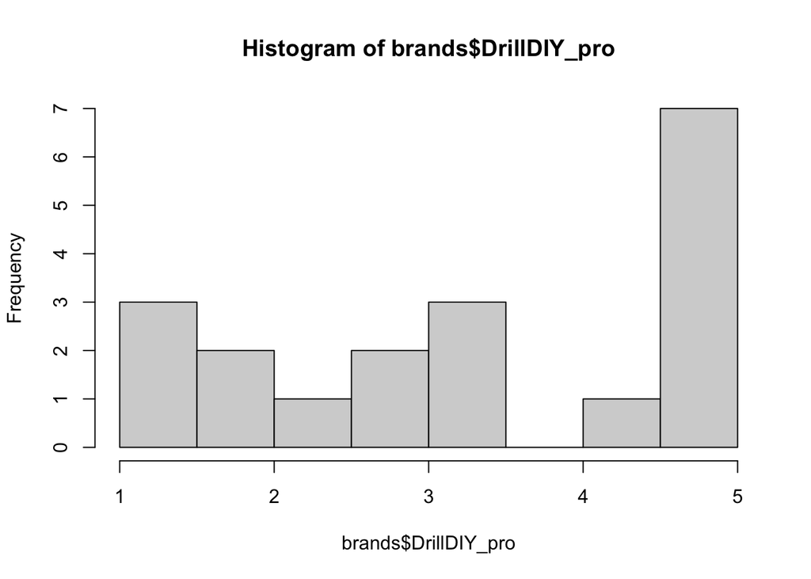

```r
hist(brands$DrillDIY_pro)
```

- Goood spread. Many high-end, low end, and some in between
- **User orientation (DrillDIY_pro):** Positions cordless-drill brands from occasional homeowner/DIY use to prosumer to frequent professional/trade use under demanding job-site conditions.